# Flight Price Web Scraping

Marcus

February 14, 2019

## Flight Web Scraping

### Introduction

I’m a pretty frequent traveller, and this means I have spent some time of searching for flights (actually I dont want to track exactly how much time I have spent on such a crappy task). Price is of course one important factor when deciding exact travel dates, butI guess I’m not the only one noticing the fluctuations in flight prices. Often you find a flight, everything looked good but just had to check a doublecheck the schedule. The next day, all clear, just book the flight - but now the price was waay higher than it was yesterday.

To take a closer look at this without having to search for flights every day, I wrote an R-script to scrape the web for prices. As some sites are making it hard to scrape the data through an automated script (for example recaptcha), the first step was to identify a site without such issues. After some testing, Expedia turned out to be a good candidate.

### Exploratory Analysis

As always when it comes to analysis, the first step is to load the data and check it out.

```
##     Journey      Origin     Destination    DepartureDate
##  LON-BKK:  643   BER:2365   BER:2634    2019-02-08:  730
##  LON-STO:  643   BKK:2612   BKK:2706    2019-02-07:  695
##  LON-SIN:  633   CPH:2635   CPH:2577    2019-02-03:  688
##  STO-LON:  567   LON:2907   LON:2588    2019-02-06:  679
##  SIN-BER:  554   SIN:2644   SIN:2697    2019-02-05:  668
##  SIN-CPH:  545   STO:2716   STO:2677    2019-02-04:  657
##  (Other):12294                          (Other)   :11762
##       ReturnDate                   TravelDates         ScrapeDate
##  2019-02-13:  720   2019-02-08-2019-02-13:  268   2019-01-14: 1157
##  2019-02-10:  717   2019-02-05-2019-02-10:  257   2019-01-16:  822
##  2019-02-14:  705   2019-02-06-2019-02-11:  257   2019-01-21:  811
##  2019-02-11:  687   2019-02-08-2019-02-14:  243   2019-01-20:  810
##  2019-02-09:  657   2019-02-09-2019-02-14:  243   2019-01-24:  810
##  2019-02-15:  645   2019-02-07-2019-02-12:  238   2019-01-25:  810
##  (Other)   :11748   (Other)              :14373   (Other)   :10659
##      price       DaysBeforeDeparture
##  Min.   :   98   Min.   : 6.00
##  1st Qu.:  749   1st Qu.: 8.00
##  Median : 5016   Median :11.00
##  Mean   : 3793   Mean   :10.85
##  3rd Qu.: 6303   3rd Qu.:13.00
##  Max.   :16087   Max.   :33.00
##
```

```
##   Journey Origin Destination DepartureDate ReturnDate
## 1 BER-BKK    BER         BKK    2019-01-20 2019-01-24
## 2 BER-BKK    BER         BKK    2019-01-20 2019-01-25
## 3 BER-BKK    BER         BKK    2019-01-20 2019-01-26
## 4 BER-BKK    BER         BKK    2019-01-20 2019-01-27
## 5 BER-BKK    BER         BKK    2019-01-21 2019-01-25
## 6 BER-BKK    BER         BKK    2019-01-21 2019-01-26
##             TravelDates ScrapeDate price DaysBeforeDeparture
## 1 2019-01-20-2019-01-24 2019-01-14  5384                   6
## 2 2019-01-20-2019-01-25 2019-01-14  5153                   6
## 3 2019-01-20-2019-01-26 2019-01-14  5384                   6
## 4 2019-01-20-2019-01-27 2019-01-14  5485                   6
## 5 2019-01-21-2019-01-25 2019-01-14  5858                   7
## 6 2019-01-21-2019-01-26 2019-01-14  5858                   7
```

- 6 different cities are being evaluated
- Departure, Return and date when the data was scraped is available. This means that we can compare prices of the same TravelDates for different Scraping-dates

Lets check how the data points are distributed between Journey and ScrapeDate.

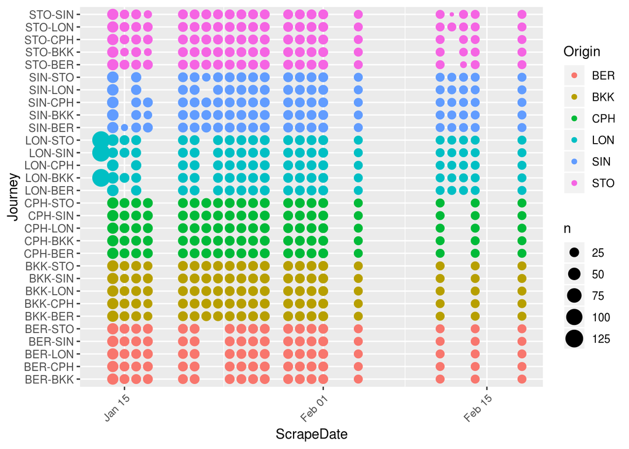

The data for 13th and 14th of January has more datapoints than other dates, but otherwise it looks fine. There are some gaps, which has to do with errors when the scraping was performed. I’ll remove the data before the 15th of Januray for consistency along all Journeys. In order to compare prices for a given journey and date along the scraping date, a standardized variable `price_std` is created. Standardization means that the variable has mean of 0 and standard deviation of 1.

```r
df <- filter(df, ScrapeDate>="2019-01-15") %>%
  group_by(Journey, Origin, TravelDates) %>%
  mutate(price_std = scale(price), # Standardize price per scrapedate
         n=n())

group_by(df, Journey, Origin, TravelDates, n) %>%
  summarize(mean=mean(price_std),
            stdev = sd(price_std)) %>%
  filter(n>2) %>%
  head(n=10)
```

```
## # A tibble: 10 x 6
## # Groups:   Journey, Origin, TravelDates [10]
##    Journey Origin TravelDates               n      mean stdev
##    <fct>   <fct>  <fct>                 <int>     <dbl> <dbl>
##  1 BER-BKK BER    2019-01-23-2019-01-28     3  5.91e-14 1
##  2 BER-BKK BER    2019-01-23-2019-01-29     3  5.91e-14 1
##  3 BER-BKK BER    2019-01-23-2019-01-30     3  9.25e-16 1.000
##  4 BER-BKK BER    2019-01-24-2019-01-29     3 -2.78e-17 1
##  5 BER-BKK BER    2019-01-24-2019-01-30     3 -3.70e-17 1.000
##  6 BER-BKK BER    2019-01-24-2019-01-31     3 -5.55e-17 1
##  7 BER-BKK BER    2019-01-25-2019-01-30     3  0.       1
##  8 BER-BKK BER    2019-01-25-2019-01-31     3 -1.54e-14 1.
##  9 BER-BKK BER    2019-01-25-2019-02-01     3  0.       1.000
## 10 BER-BKK BER    2019-01-26-2019-01-31     3  1.89e-15 1
```

Lets plot the median value of the standardized prices to identify journeys with high fluctuation in prices. A median value above zero indicate that most days, the prices are varying above average.

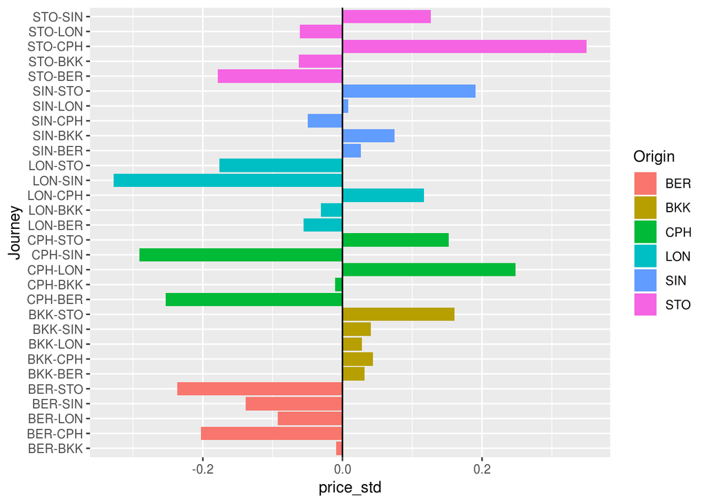

Lets dig a little deeper by checking only flights with origin STO and by plotting the values by days before departure.

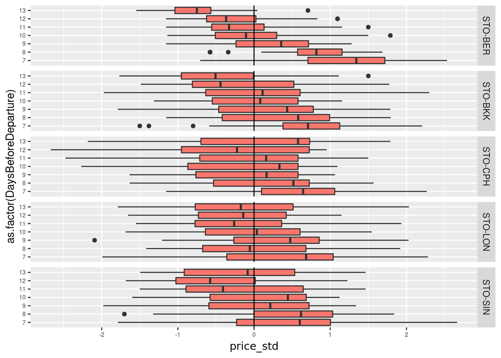

- `STO-CPH` : The deviations are not varying that much depending on days before departure, but in general the median is well above zero. The boxplot is pretty wide, indicationg high variation.
- `STO-BER` : Prices tends to go up as days before departure goes down. If you see a good price 10 days before departure, be sure to book!

In general, prices tends to go up the closer departure you get. To what extent, really depends on the journey.

Lets check out Berlin (as this is my homebase).

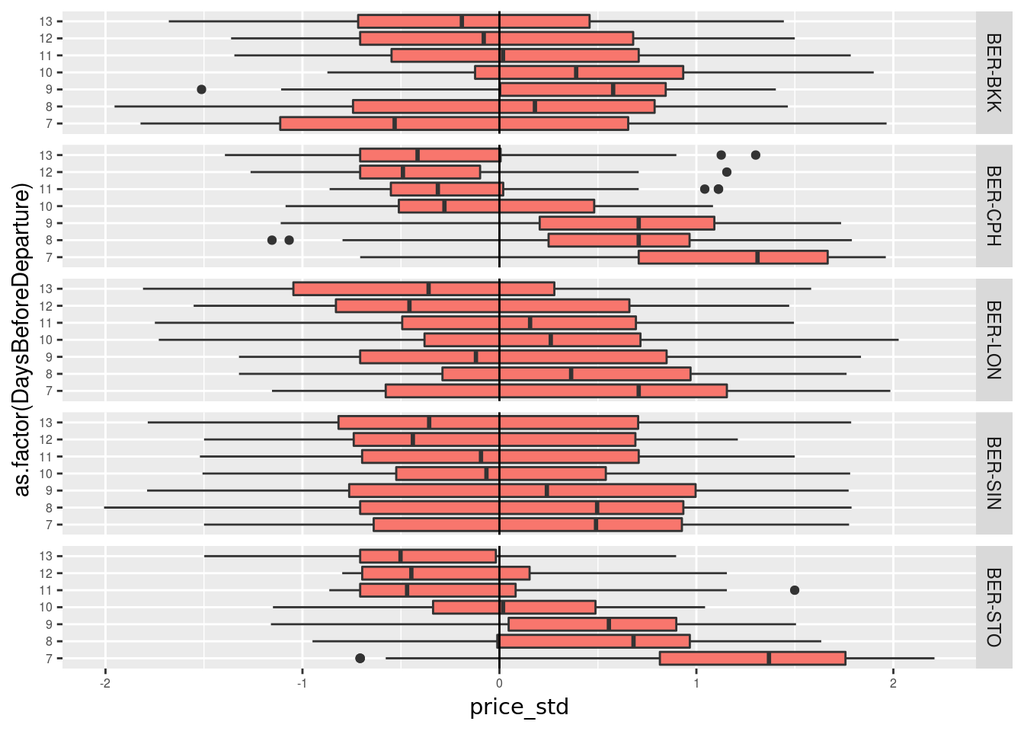

As for STO-BER, the prices of the reverted journey BER-STO are also considerably pricier closer to departure. The same trend is obvious for BER-CPH.

Finally, lets break down `BER-STO` and `BER-SIN` on TravelDates and plot the different prices depending on days before departure. The tendency that prices are increasing closer to departure more clearly for `BER-STO` is obvious - red points are much higher than for `BER-SIN`.

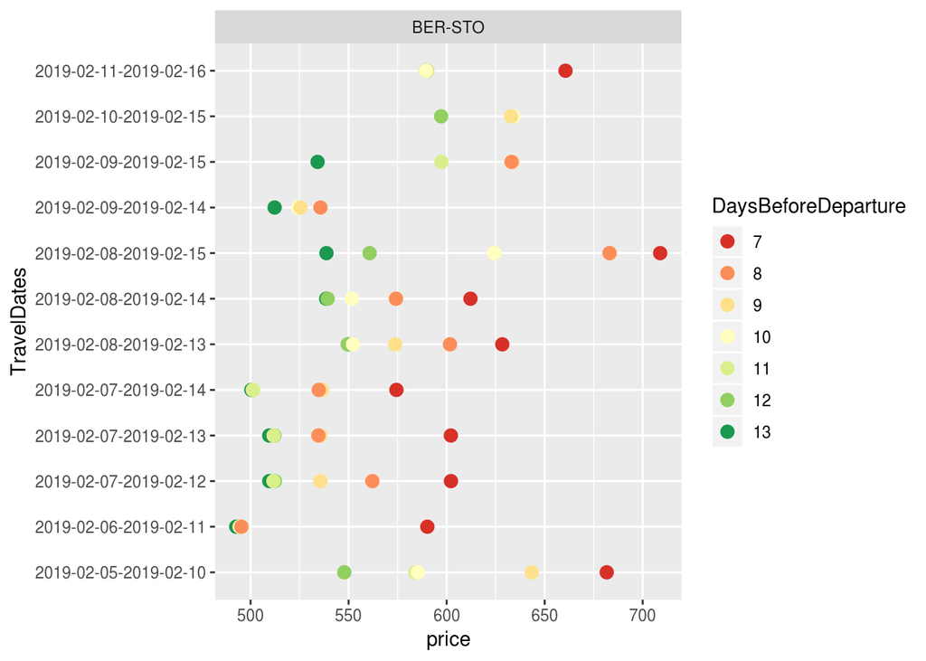

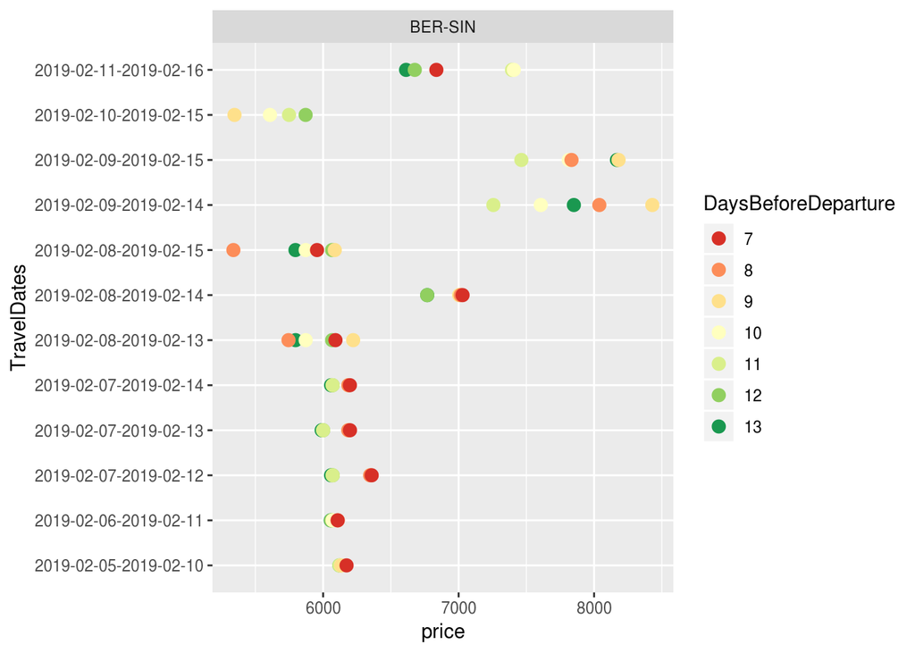

To wrap it up, the analysis is summarized in the heatmap below. Red values indicate higher prices.

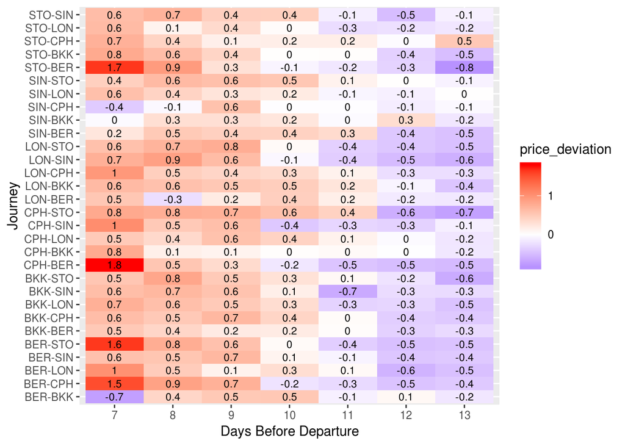

The prices for Berlin journeys are really skyrocketing. So next time I’m finding a good Berlin price 10 days ahead of departure, I will book it instantly.